# Assignment

#### Cleaning the Data

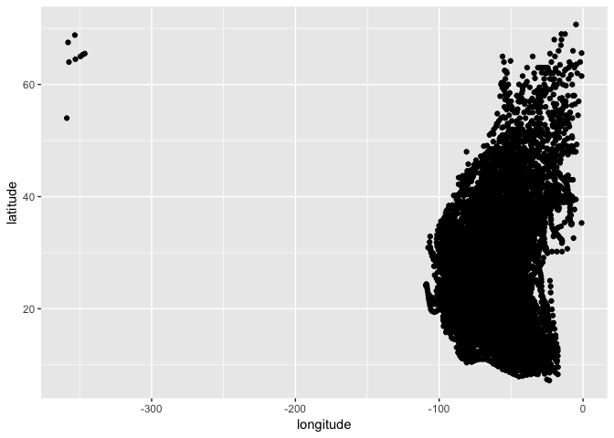

```r
#Select only the relevant cols
#create a storm_id as the concatenation of the storm name and year
#create a data_time variable describing when the storm was happening
#format the longitute to ensure that has negative values for Western emisphere
#  longitude in raw data is measured in degree West

data_tmp <- ext_tracks %>%
  select(storm_id, storm_name, month, day, hour, year, latitude, longitude, starts_with("radius_")
         ) %>%
  rename(original_id = storm_id) %>%
  mutate(storm_id = paste(storm_name, year, sep = "-"),
         date = make_datetime(year = as.integer(year),
                              month = as.integer(month),
                              day = as.integer(day),
                              hour = as.integer(hour),
                              tz = "UTC"),
         longitude = -longitude)

data_p <- data_tmp  %>%
  select(storm_id, date, latitude, longitude, starts_with("radius_"))

ggplot(data = data_p, mapping = aes(y = latitude)) +
  geom_point(aes(x = longitude))
```

```r
#convert the data to a long format
##       storm_id                date latitude longitude wind_speed  ne  nw  se  sw
## 1 Katrina-2005 2005-08-29 12:00:00     29.5     -89.6         34 200 100 200 150

data_p_34 <- data_p %>%
  select(storm_id, date, latitude, longitude,starts_with("radius_34_")) %>%
  rename(ne = radius_34_ne, se = radius_34_se, nw = radius_34_nw, sw = radius_34_sw) %>%
  mutate(wind_speed = 34)

data_p_50 <- data_p %>%
  select(storm_id, date, latitude, longitude,starts_with("radius_50_")) %>%
  rename(ne = radius_50_ne, se = radius_50_se, nw = radius_50_nw, sw = radius_50_sw) %>%
  mutate(wind_speed = 50)

data_p_64 <- data_p %>%
  select(storm_id, date, latitude, longitude,starts_with("radius_64_")) %>%
  rename(ne = radius_64_ne, se = radius_64_se, nw = radius_64_nw, sw = radius_64_sw) %>%
  mutate(wind_speed = 64)

data_p_long <- rbind(data_p_34, data_p_50, data_p_64) %>%
  arrange(storm_id, date, wind_speed)

data_p_long[data_p_long$storm_id == "KATRINA-2005" & data_p_long$date == ymd_hms("2005-08-29 12:00:00"),]
```

```
## # A tibble: 3 x 9
##       storm_id                date latitude longitude    ne    se    sw
##          <chr>              <dttm>    <dbl>     <dbl> <int> <int> <int>
## 1 KATRINA-2005 2005-08-29 12:00:00     29.5     -89.6   200   200   150
## 2 KATRINA-2005 2005-08-29 12:00:00     29.5     -89.6   120   120    75
## 3 KATRINA-2005 2005-08-29 12:00:00     29.5     -89.6    90    90    60
## # ... with 2 more variables: nw <int>, wind_speed <dbl>
```

### Experiment with the `geosphere` package

*‘As a hint, notice that the wind radii geom essentially shows a polygon for each of the wind levels. One approach to writing this geom is therefore to write the hurricane stat / geom combination that uses the wind radii to calculate the points along the boundary of the polygon and then create a geom that inherits from a polygon geom.’*

**Point at distance and bearing**

As suggested the `destPoint` function can create polygons that can be used to map the wind extension in each quadrant. See the example below.

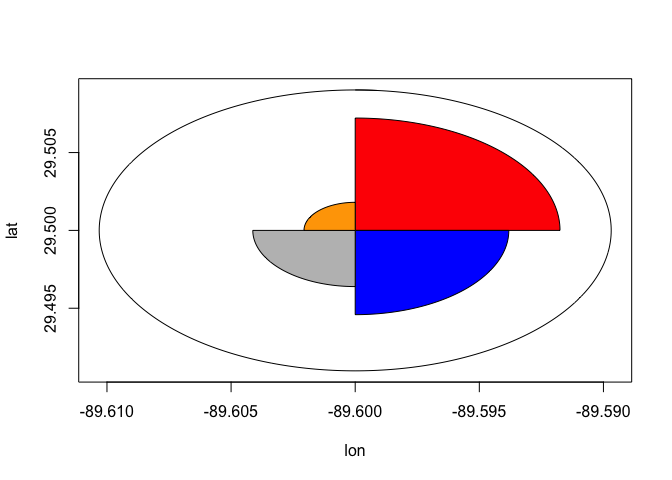

```r
center <- c(-89.6, 29.5)
#p: longitude and latitude (degrees) of the starting point
#b: bearing in degress
#d: distance in meters
circle <- destPoint(center, b=0:365, d = 1000)

circle_ne <- destPoint(center, b=0:90, d=800)
circle_ne <- rbind(center, circle_ne)

circle_se <- destPoint(center, b=90:180, d=600)
circle_se <- rbind(center, circle_se)

circle_sw <- destPoint(center, b=180:270, d=400)
circle_sw <- rbind(center, circle_sw)

circle_nw <- destPoint(center, b=270:360, d=200)
circle_nw <- rbind(center, circle_nw)

plot(circle, type='l')
polygon(circle_ne, col = "red")
polygon(circle_se, col = "blue")
polygon(circle_sw, col = "gray")
polygon(circle_nw, col = "orange")
```